# 09 Machine Learning mit caret

Martin Hanewald

2019-02-19

## Packages

```r
library(tidyverse)
library(caret)
library(knitr)
library(DT)
library(GGally)
library(Metrics)
```

## Überblick

Das `caret` Paket ist der einfachste Weg um eine Vielzahl von Machine-Learning Techniken anzuwenden. Es verfügt über ein einheitliches Interface um zahlreiche Modelle aus anderen Paketen anzusprechen.

Die zentralen FUnktionen sind:

- `createDataPartition()`: Splitting in Training- und Testset
- `train()`: Training von Modellen
- `trainControl()`: Steuerung der Validierungsmethodik und Parametertuning
- `preProcess()`: Optionales Pre-Processing der Daten (Centering, Scaling, etc.)
- `predict()`: Erzeugung der Prediction
- `resamples()`: Erzeugung von Cross-Validation Metriken mit `summary()`und `bwplot()`

## Dataset

Wir betrachten einen mitgelieferten Datensatz über den Zusammenhang zwischen Häuserpreisen (`price`) und verschiedenen Hauseigenschaften wie Größe, Lage, Anzahl Badezimmer, etc.

```r
data(Sacramento, package='caret')
Sacramento <- Sacramento %>% as_tibble()
# für scrollbaren HTML Output
Sacramento %>% sample_n(20) %>% datatable(options = list(scrollX=T))
```

|  | city | zip | beds | baths | sqft | type | price | latitude | longitude |
| --- | --- | --- | --- | --- | --- | --- | --- | --- | --- |
| 1 | GOLD_RIVER | z95670 | 2 | 2 | 1520 | Residential | 299000 | 38.62869 | -121.261669 |
| 2 | CITRUS_HEIGHTS | z95621 | 4 | 2 | 1280 | Residential | 167293 | 38.715781 | -121.298519 |
| 3 | SACRAMENTO | z95864 | 3 | 1 | 1643 | Residential | 99000 | 38.588672 | -121.373916 |
| 4 | GALT | z95632 | 5 | 4 | 3746 | Residential | 420000 | 38.271646 | -121.286848 |
| 5 | SACRAMENTO | z95826 | 3 | 2 | 1280 | Residential | 192067 | 38.560767 | -121.377471 |
| 6 | SACRAMENTO | z95842 | 4 | 2 | 1578 | Residential | 195000 | 38.693071 | -121.332365 |
| 7 | SACRAMENTO | z95841 | 3 | 2 | 1120 | Residential | 178000 | 38.658734 | -121.357196 |
| 8 | SACRAMENTO | z95815 | 2 | 1 | 1011 | Residential | 85000 | 38.6238 | -121.439872 |
| 9 | SACRAMENTO | z95818 | 2 | 1 | 1144 | Residential | 299000 | 38.556844 | -121.490769 |
| 10 | CITRUS_HEIGHTS | z95621 | 3 | 2 | 1343 | Residential | 284893 | 38.715853 | -121.317095 |

[output cut: 10 more lines]

## Exploration

Ein einfacher Pairs Plot zwischen zwei ausgewählten Variabeln `sqft` und `baths` zeigt eine deutliche positivte Korrelation.

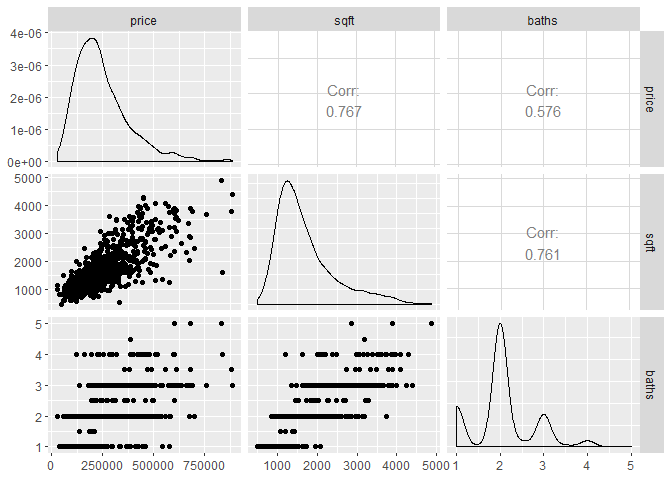

```r
Sacramento %>% select(price, sqft, baths) %>% ggpairs()
```

## Splitting und Training

Wir splitten den Datensatz gemäß der 80/20 Faustregel.

```r
in_train <- createDataPartition(Sacramento$price, p = .8, list = FALSE)

training <- Sacramento[ in_train,]
testing  <- Sacramento[-in_train,]
```

Danach fitten wir ein einfaches lineares Modell sowie einen Decision Tree.

Als Sampling Methode wählen wir die Cross-Validation (method=‘cv’) und einige Pre-Processing Schritte für numerische Variablen. Als einzigen Prädiktor wählen wir zunächst nur die Variable `sqft`.

```r
fit_lm <- train(price ~ sqft,
             trControl = trainControl(method='cv'),
             preProcess = c('center', 'scale', 'zv'),
             method = 'lm',
             data=training)
```

```r
fit_dtree <- train(price ~ sqft,
             trControl = trainControl(method='cv'),
             preProcess = c('center', 'scale', 'zv'),
             method = 'rpart',
             data=training)
```

## Evaluation

Die Evaluation anhand der Kreuzvalidierungssamples zeigt das lineare Modell eindeutig im Vorteil.

```r
res <- resamples(list(lm = fit_lm, dtree = fit_dtree))
res %>% summary()
```

```
#>
#> Call:
#> summary.resamples(object = .)
#>
#> Models: lm, dtree
#> Number of resamples: 10
#>
#> MAE
#>           Min.  1st Qu.   Median     Mean  3rd Qu.     Max. NA's
#> lm    49662.66 56608.57 61138.46 59482.88 63998.12 64976.63    0
#> dtree 59116.95 62521.25 68131.29 67158.75 69759.41 77328.92    0
#>
#> RMSE
#>           Min. 1st Qu.   Median     Mean  3rd Qu.     Max. NA's
#> lm    63948.38 70316.6 78445.73 79636.29 85436.34 111279.2    0
#> dtree 74841.75 79334.8 89396.70 88917.08 92501.02 114739.1    0
#>
#> Rsquared
#>            Min.   1st Qu.    Median      Mean   3rd Qu.      Max. NA's
#> lm    0.4305718 0.5831811 0.6119248 0.6102292 0.6510016 0.7443224    0
#> dtree 0.3947227 0.4225706 0.5244397 0.5151145 0.6057425 0.6563568    0
```

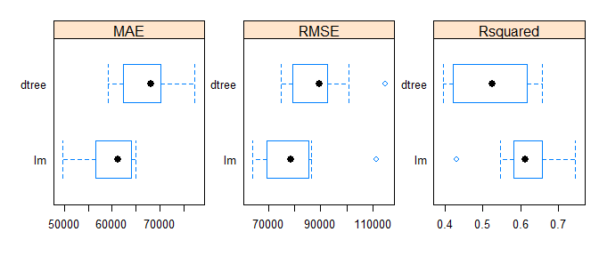

```r
res %>% bwplot(scales='free')
```

Auch die visuelle Inspektion der Prediction auf Basis des Testdatensatzes zeigt die Schwächen des Decision Tree Ansatzes.

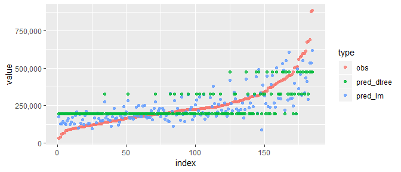

```r
ans <- tibble(obs = testing$price,
              pred_lm = predict(fit_lm, testing),
              pred_dtree = predict(fit_dtree, testing))

ans %>% arrange(obs) %>%
    mutate(index = row_number(obs)) %>%
    gather(type, value, -index) %>%
    ggplot(aes(x=index, y =value, color=type)) + geom_point(alpha=.8) +
    scale_y_continuous(labels = scales::comma)
```

Abschließende Beurteilung der Güte auf dem Testset anhand der Performance-Kennzahl MAPE (Mean Absolute Percentage Error).

```r
ans %>%
    summarise(mape_lm = mape(obs, pred_lm),
              mape_dtree = mape(obs, pred_dtree),
              mase_lm = mase(obs, pred_lm),
              mase_dtree = mase(obs, pred_dtree))
```

```
#> # A tibble: 1 x 4
#>   mape_lm mape_dtree mase_lm mase_dtree
#>     <dbl>      <dbl>   <dbl>      <dbl>
#> 1   0.320      0.415    2.52       2.92
```

## Aufgabe: Verbessere obiges Modell durch Variation

1. Probiere ein Ensemble Modell aus (siehe caret Doku)
2. Füge zusätzliche Variablen hinzu

[figure not shown]